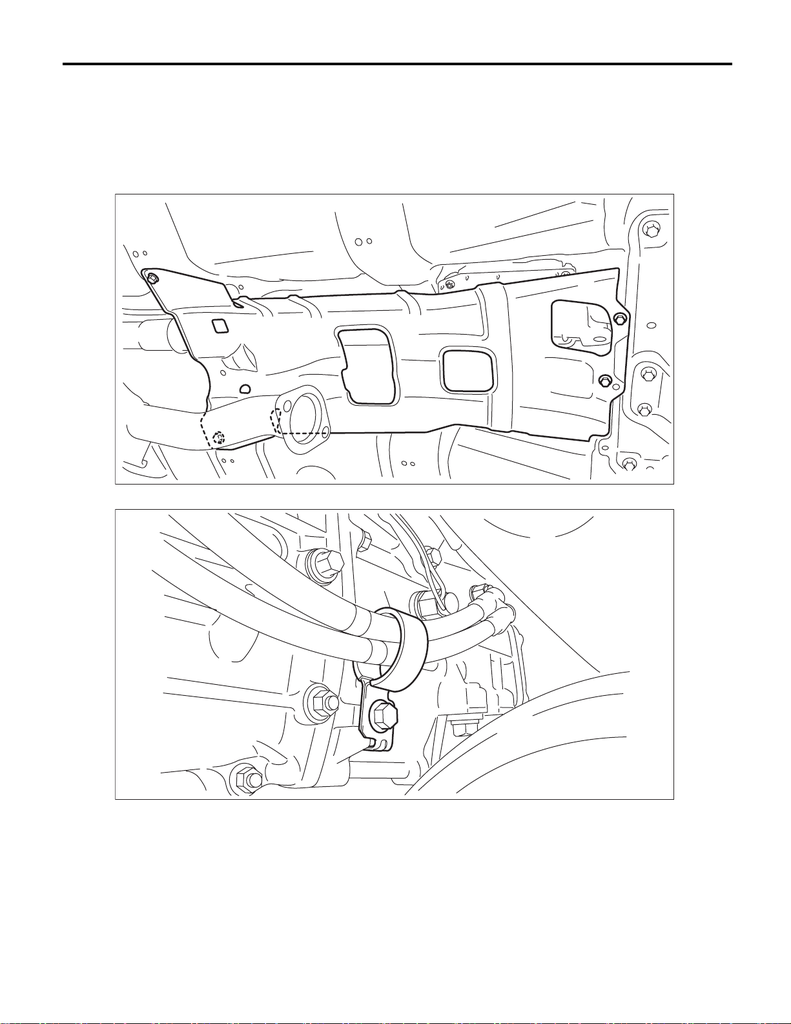

CS-85

MT Gear Shift Cable

CONTROL SYSTEMS

8. MT Gear Shift Cable

A: REMOVAL

1) Disconnect the ground terminal from battery sensor. <Ref. to NT-5, BATTERY, NOTE, Note.>

2) Lift up the vehicle.

3) Remove the center exhaust pipe (rear). <Ref. to EX(w/o STI)-35, REMOVAL, Center Exhaust Pipe.>

4) Remove the center exhaust cover.

5) Remove the cable clamp.

(A) Cable clamp

CS-01671

CS-01673

(A)

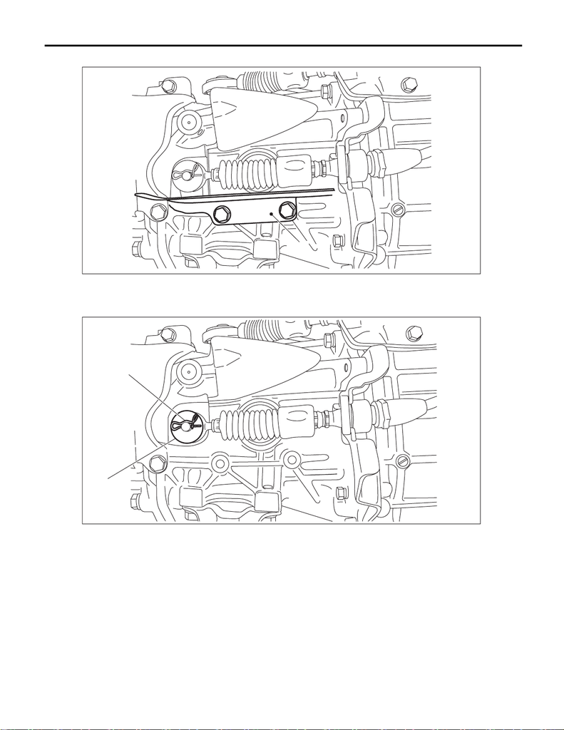

CS-86

MT Gear Shift Cable

CONTROL SYSTEMS

6) Remove the dust cover.

7) Remove the snap pin and washer.

(A) Dust cover

(A) Snap pin (B) Washer

CS-01553

(A)

CS-01850

(A)

(B)

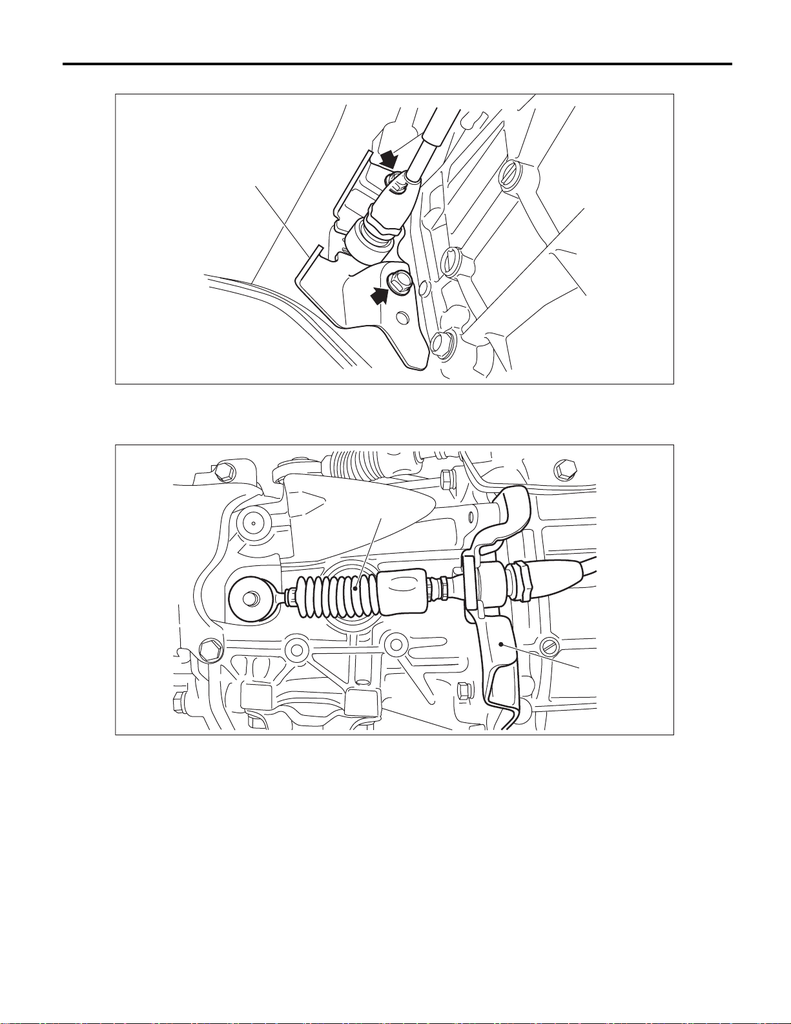

CS-87

MT Gear Shift Cable

CONTROL SYSTEMS

8) Remove the bolts holding the shift bracket.

9) Remove the shift bracket together with the MT gear shift cable.

(A) Shift bracket

(A) MT gear shift cable (B) Shift bracket

CS-01479

(A)

CS-01555

(B)

(A)

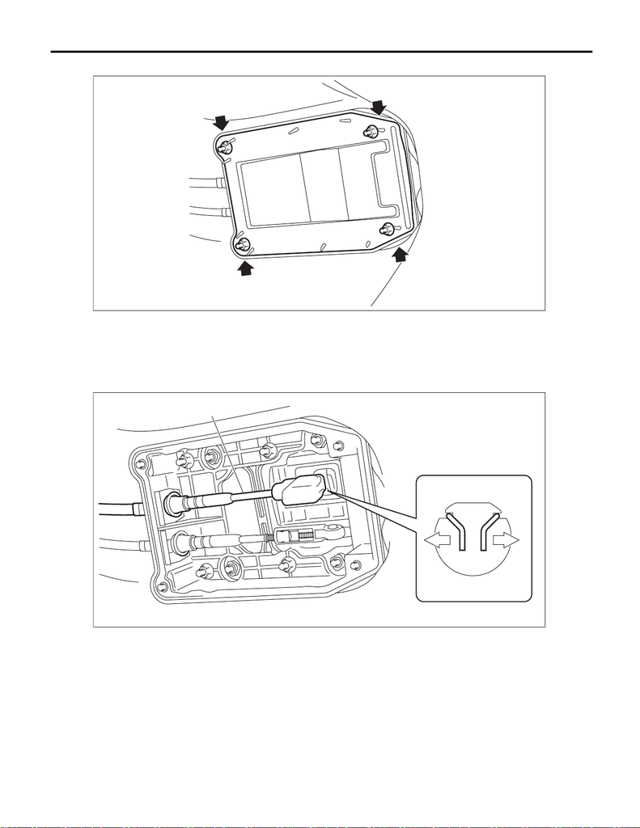

CS-88

MT Gear Shift Cable

CONTROL SYSTEMS

10) Remove the cable cover plate.

11) Disconnect the MT gear shift cable.

CAUTION:

Be careful not to deform the cable inner.

NOTE:

Pull out down the MT gear shift cable to spread the spring.

(A) MT gear shift cable

CS-01848

CS-01452

(A)

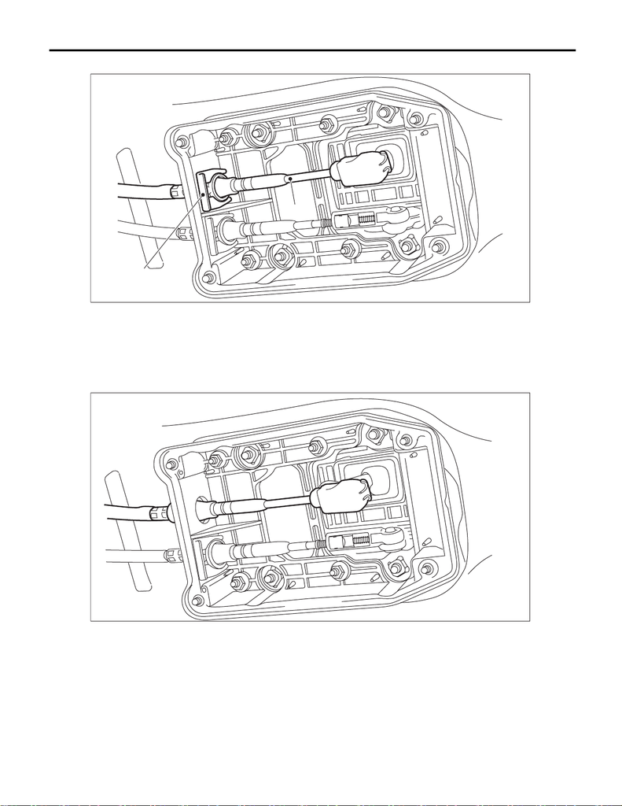

CS-89

MT Gear Shift Cable

CONTROL SYSTEMS

12) Remove the clamp.

13) Pull out the MT gear shift cable.

CAUTION:

• Do not bend MT gear shift cable at a sharp angle.

• Do not twist the cable inner excessively.

(A) Clamp (B) MT gear shift cable

CS-01676

(A)

(B)

CS-01675

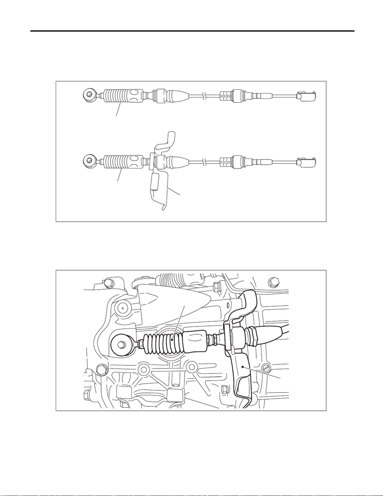

CS-90

MT Gear Shift Cable

CONTROL SYSTEMS

B: INSTALLATION

CAUTION:

• Do not bend MT gear shift cable at a sharp angle.

• When replacing the new MT gear shift cable, secure it to shift bracket with the clamps, be careful

not to mistake the installing direction.

1) Install the shift bracket together with the MT gear shift cable.

Tightening torque:

18 N·m (1.8 kgf-m, 13.3 ft-lb)

(A) Old MT gear shift cable (B) New MT gear shift cable (C) Shift bracket

(A) MT gear shift cable (B) Shift bracket

CS-01152

(A)

(B)

(C)

CS-01555

(B)

(A)

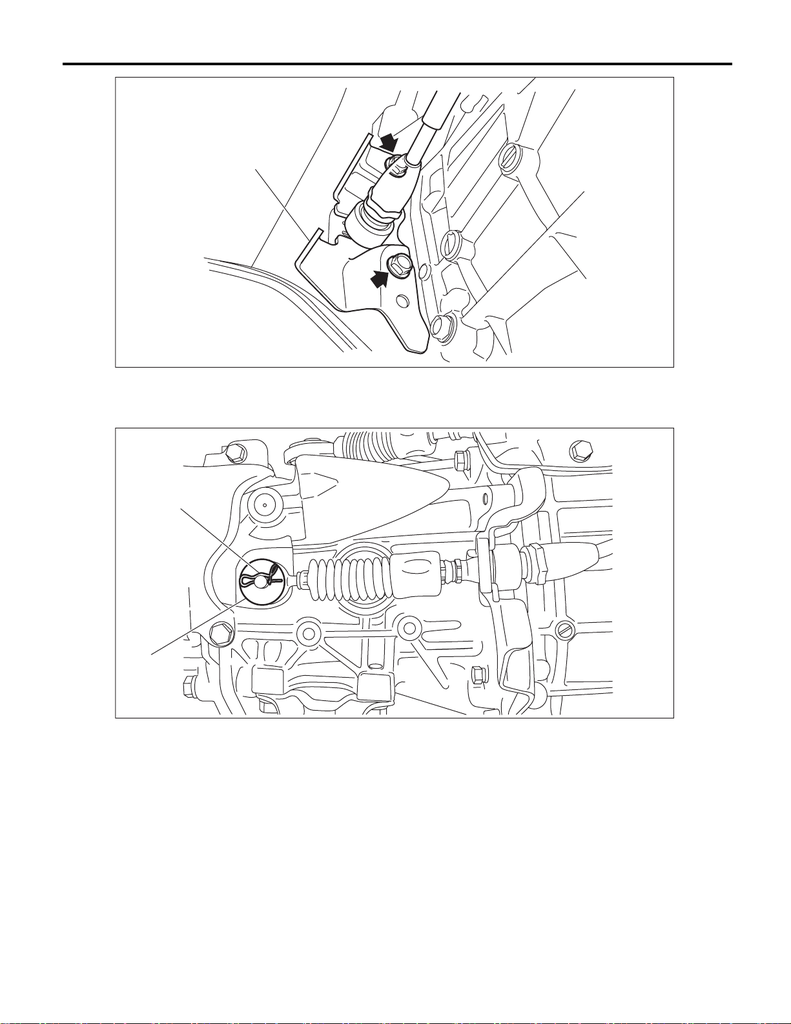

CS-91

MT Gear Shift Cable

CONTROL SYSTEMS

2) Install the snap pin and washer.

3) Install the dust cover.

Tightening torque:

15 N·m (1.5 kgf-m, 11.1 ft-lb)

(A) Shift bracket

(A) Snap pin (B) Washer

CS-01479

(A)

CS-01850

(A)

(B)

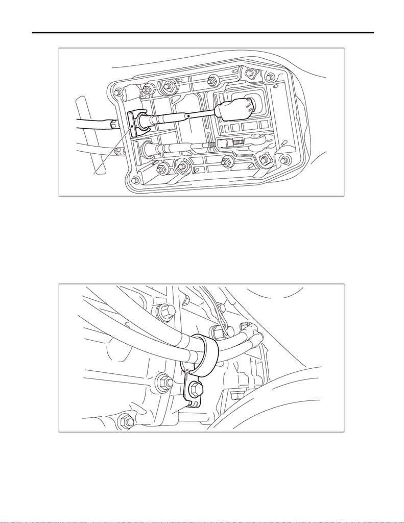

CS-92

MT Gear Shift Cable

CONTROL SYSTEMS

4) Insert the MT gear shift cable into cable cover assembly, and install the clamp.

5) Connect the MT gear shift cable.

6) Attach the cable cover plate.

Tightening torque:

7.5 N·m (0.8 kgf-m, 5.5 ft-lb)

7) Insert the MT gear shift cable into cable clamp, and install to the transmission.

Tightening torque:

18 N·m (1.8 kgf-m, 13.3 ft-lb)

(A) Clamp (B) MT gear shift cable

(A) Cable clamp

CS-01676

(A)

(B)

CS-01673

(A)

[figure not shown]

CS-93

MT Gear Shift Cable

CONTROL SYSTEMS

8) Install the center exhaust cover.

Tightening torque:

18 N·m (1.8 kgf-m, 13.3 ft-lb)

9) Install the center exhaust pipe (rear). <Ref. to EX(w/o STI)-41, INSTALLATION, Center Exhaust Pipe.>

10) Lower the vehicle.

11) Connect the ground terminal to battery sensor. <Ref. to NT-5, BATTERY, NOTE, Note.>

12) Make sure the gears can be shifted accurately into each gear.